# DATA 607 — Week 9: Working with Web APIs

Assignment Approach: Analyzing Bestselling Books Using the New York Times API

Author

Patricio Romero

Published

November 1, 2026

## 1 Project Overview

The goal of this assignment is to practice collecting data from a web API and organizing it with R. I selected the New York Times Books API to explore the Hardcover Fiction bestseller list.

I downloaded a sample of 15 books and saved the results in JSON, CSV, and SQLite formats. This project explains the API connection, data collection, database structure, cleaning process, and data validation. It also includes an analysis of bestseller rankings, authors, weeks on the list, and ranking changes.

## 2 Research Questions

I will investigate these questions:

1. What are the top five bestselling hardcover fiction books, and what is each book’s rank?
2. Which authors appear on the bestseller list?
3. How many weeks have the top five books been on the list?

The bestseller **rank** is the book’s position on this list. It is not a measure of the number of copies sold.

## 3 Data Source and API Endpoint

**Source:** [New York Times Books API](https://developer.nytimes.com/docs/books-product/1/overview)

**Endpoint:**

`https://api.nytimes.com/svc/books/v3/lists/current/hardcover-fiction.json`

- HTTP method: `GET`
- Query parameter: `api-key`
- Response format: JSON
- Selected list: Hardcover Fiction
- Authentication: API key stored privately as `NYT_API_KEY` in `~/.Renviron`

The endpoint returns the latest available list. The saved sample used in this Approach has a **print publication date of November 8, 2026**. The print date can be later than the web release date. Results may change when the API is called again.

## 4 API Connection and JSON Download

I created an API application and saved my key in an R environment variable. The actual request is performed in `fetch_nyt_books.R`, which saves the original JSON and creates the cleaned CSV and SQLite records.

The following is the main request code. It is shown for documentation and is **not re-run during rendering**, so this report uses the same saved sample each time.

```r
library(httr)
library(jsonlite)

api_key <- Sys.getenv("NYT_API_KEY")
stopifnot(nzchar(api_key))

endpoint <- paste0(
  "https://api.nytimes.com/svc/books/v3/",
  "lists/current/hardcover-fiction.json"
)

response <- httr::GET(
  endpoint,
  query = list("api-key" = api_key),
  httr::timeout(30)
)
httr::stop_for_status(response)

raw_json <- httr::content(
  response,
  as = "text",
  encoding = "UTF-8"
)

# The complete fetch_nyt_books.R script validates the response,
# loads SQLite, and saves the original JSON and tidy CSV.
```

The original response is saved as `data/nyt_hardcover_fiction_raw.json`. I do not include my API key or secret in the submission.

## 5 Load JSON, Create the Database, and Verify the Tables

I used `jsonlite` to load the downloaded JSON file. Then I used `DBI` and `RSQLite` to create a local database and verify the data. The SQL statements below create the tables if necessary; existing records are not deleted.

```r
library(jsonlite)
library(dplyr)
library(DBI)
library(RSQLite)
library(knitr)

nyt_json <- jsonlite::fromJSON(
  "data/nyt_hardcover_fiction_raw.json",
  simplifyVector = FALSE
)
json_books <- nyt_json$results$books

data.frame(
  List = as.character(nyt_json$results$list_name),
  Print_Date = as.character(nyt_json$results$published_date),
  Books = length(json_books)
) |>
  knitr::kable(caption = "NYT Hardcover Fiction: API Response Summary", col.names = c("Bestseller List", "Publication Date", "Number of Books"))
```

NYT Hardcover Fiction: API Response Summary

| Bestseller List | Publication Date | Number of Books |
| --- | --- | --- |
| Hardcover Fiction | 2026-11-08 | 15 |

This is how the two database tables are created in the actual project:

```r
con <- DBI::dbConnect(
  RSQLite::SQLite(), "data/nyt_books.sqlite"
)
DBI::dbExecute(con, "CREATE TABLE IF NOT EXISTS bestseller_books (
  list_name TEXT NOT NULL,
  published_date TEXT NOT NULL,
  rank INTEGER NOT NULL,
  rank_last_week INTEGER,
  weeks_on_list INTEGER,
  title TEXT NOT NULL,
  author TEXT,
  publisher TEXT,
  primary_isbn13 TEXT,
  fetched_at_utc TEXT NOT NULL,
  PRIMARY KEY (list_name, published_date, rank)
)")
```

```
[1] 0
```

```r
DBI::dbExecute(con, "CREATE TABLE IF NOT EXISTS download_log (
  fetched_at_utc TEXT PRIMARY KEY,
  endpoint TEXT NOT NULL,
  list_name TEXT NOT NULL,
  published_date TEXT,
  records INTEGER NOT NULL
)")
```

```
[1] 0
```

```r
knitr::kable(
  data.frame(
    Table_Name = c("bestseller_books", "download_log"),
    Description = c("Stores the books, authors, ranks, and weeks on the list",
                    "Records when the API data was downloaded")
  ),
  col.names = c("Database Table", "Purpose"),
  caption = "SQLite Database Structure",
  row.names = FALSE
)
```

SQLite Database Structure

| Database Table | Purpose |
| --- | --- |
| bestseller_books | Stores the books, authors, ranks, and weeks on the list |
| download_log | Records when the API data was downloaded |

The downloader `fetch_nyt_books.R` already inserted the downloaded records. The query below shows them directly from SQLite:

```r
# Get the publication date and list name from JSON
sample_date <- as.character(nyt_json$results$published_date)
sample_list <- as.character(nyt_json$results$list_name)

# Import records for the selected list and date
database_books <- DBI::dbGetQuery(
  con,
  "SELECT list_name, published_date, rank, title, author,
          weeks_on_list, rank_last_week, publisher
   FROM bestseller_books
   WHERE published_date = ?
   AND list_name = ?
   ORDER BY rank",
  params = list(sample_date, sample_list)
)

database_count <- nrow(database_books)
json_count <- length(json_books)

knitr::kable(
  data.frame(Source = c("JSON response", "SQLite database"),
             Records = c(json_count, database_count)),
  col.names = c("Data Source", "Number of Books"),
  caption = "Record Count Validation: JSON vs. SQLite",
  row.names = FALSE
)
```

Record Count Validation: JSON vs. SQLite

| Data Source | Number of Books |
| --- | --- |
| JSON response | 15 |
| SQLite database | 15 |

```r
knitr::kable(
  head(database_books[, c("rank", "title", "author", "weeks_on_list")]),
  col.names = c("Bestseller Rank", "Book Title", "Author(s)", "Weeks on List"),
  caption = "First Six Books Stored in SQLite",
  row.names = FALSE
)
```

First Six Books Stored in SQLite

| Bestseller Rank | Book Title | Author(s) | Weeks on List |
| --- | --- | --- | --- |
| 1 | THRESHING DAY | Rebecca Yarros | 4 |
| 2 | MISS WOLCOTT’S GHOST | Louise Penny | 1 |
| 3 | A MARRIED LITTLE CHRISTMAS | Abby Jimenez | 1 |
| 4 | THE FAMILY CROSS | James Patterson | 1 |
| 5 | CHAIN REACTION | Lee Child and Andrew Child | 1 |
| 6 | THE FRENCH ILLUSION | John Grisham | 4 |

```r
DBI::dbDisconnect(con)
```

## 6 Data Cleaning and Quality Review

The API returns nested JSON. I converted selected fields into a tidy data frame. Each row represents one book, with columns for rank, title, author, and weeks on the list.

```r
get_text <- function(x) {
  if (is.null(x) || length(x) == 0) {
    return(NA_character_)
  }
  as.character(x[[1]])
}

get_number <- function(x) {
  suppressWarnings(as.integer(get_text(x)))
}

books_clean <- dplyr::bind_rows(
  lapply(json_books, function(book) {
    data.frame(
      rank = get_number(book$rank),
      title = get_text(book$title),
      author = get_text(book$author),
      weeks_on_list = get_number(book$weeks_on_list),
      rank_last_week = get_number(book$rank_last_week),
      stringsAsFactors = FALSE
    )
  })
) |>
  dplyr::arrange(rank)

quality_check <- data.frame(
  Check = c(
    "Total Books",
    "Missing Values",
    "Empty Titles",
    "Empty Authors",
    "Duplicate Ranks",
    "Invalid Ranks",
    "Negative Week Counts",
    "JSON and SQLite Counts Match"
  ),
  Result = c(
    nrow(books_clean),
    sum(is.na(books_clean)),
    sum(!is.na(books_clean$title) &
          trimws(books_clean$title) == ""),
    sum(!is.na(books_clean$author) &
          trimws(books_clean$author) == ""),
    sum(duplicated(books_clean$rank)),
    sum(is.na(books_clean$rank) |
          books_clean$rank < 1),
    sum(books_clean$weeks_on_list < 0, na.rm = TRUE),
    as.character(nrow(books_clean) == database_count)
  )
)

knitr::kable(
  quality_check,
  col.names = c("Validation Check", "Result"),
  caption = "Data Cleaning and Quality Review",
  row.names = FALSE
)
```

Data Cleaning and Quality Review

| Validation Check | Result |
| --- | --- |
| Total Books | 15 |
| Missing Values | 0 |
| Empty Titles | 0 |
| Empty Authors | 0 |
| Duplicate Ranks | 0 |
| Invalid Ranks | 0 |
| Negative Week Counts | 0 |
| JSON and SQLite Counts Match | TRUE |

## 7 Preliminary Answers to the Research Questions

This is a **small first look**, not the final analysis. This section provides an initial review of the data. The Code Base below includes additional analysis, visualizations, and interpretations.

**Question 1: What are the top five books and their rankings?**

```r
top_five <- books_clean |>
  dplyr::arrange(rank) |>
  dplyr::slice_head(n = 5) |>
  dplyr::select(rank, title, author, weeks_on_list)

knitr::kable(
  top_five,
  col.names = c("Bestseller Rank", "Book Title", "Author(s)", "Weeks on List"),
  caption = "Top Five NYT Hardcover Fiction Bestsellers",
  row.names = FALSE
)
```

Top Five NYT Hardcover Fiction Bestsellers

| Bestseller Rank | Book Title | Author(s) | Weeks on List |
| --- | --- | --- | --- |
| 1 | THRESHING DAY | Rebecca Yarros | 4 |
| 2 | MISS WOLCOTT’S GHOST | Louise Penny | 1 |
| 3 | A MARRIED LITTLE CHRISTMAS | Abby Jimenez | 1 |
| 4 | THE FAMILY CROSS | James Patterson | 1 |
| 5 | CHAIN REACTION | Lee Child and Andrew Child | 1 |

**Question 2: Which authors appear on the list?**

```r
author_counts <- books_clean |>
  dplyr::count(author, name = "books_on_list", sort = TRUE)

knitr::kable(
  author_counts,
  col.names = c("Author(s)", "Number of Books"),
  caption = "Authors Represented on the Bestseller List",
  row.names = FALSE
)
```

Authors Represented on the Bestseller List

| Author(s) | Number of Books |
| --- | --- |
| Matt Dinniman | 2 |
| Abby Jimenez | 1 |
| Barbara Kingsolver | 1 |
| Bonnie Garmus | 1 |
| Briar Boleyn | 1 |
| Freida McFadden | 1 |
| James Patterson | 1 |
| Jodi Picoult | 1 |
| John Grisham | 1 |
| Kathryn Stockett | 1 |
| Lee Child and Andrew Child | 1 |
| Louise Penny | 1 |
| Rebecca Yarros | 1 |
| Richard Paul Evans | 1 |

**Question 3: How many weeks have the top books been on the list?**

The `weeks_on_list` column in the table above answers this question. A higher number means that the book has appeared on the list for more weeks; it does not measure total sales.

## 8 Code Base Development

After completing the initial Approach, I extended the project with additional analysis.

The Code Base includes:

- Importing the saved JSON and SQLite data.
- Checking missing values and duplicate records.
- Identifying the five highest-ranked books.
- Counting books by author.
- Creating a chart of weeks on the bestseller list.
- Comparing current and previous-week rankings.
- Discussing the findings and data limitations.

The analysis uses the saved API data to keep the results consistent and reproducible.

## 9 Import Data — Code Base

```r
library(jsonlite)
library(dplyr)
library(DBI)
library(RSQLite)
library(knitr)
library(ggplot2)

# Import the original JSON file
nyt_data <- jsonlite::fromJSON(
  "data/nyt_hardcover_fiction_raw.json",
  simplifyVector = FALSE
)

# Connect to SQLite
con <- dbConnect(
  SQLite(),
  "data/nyt_books.sqlite"
)

# Import book records from SQLite
books <- DBI::dbGetQuery(
  con,
  "SELECT *
   FROM bestseller_books
   WHERE published_date = ?
   AND list_name = ?
   ORDER BY rank",
  params = list(
    as.character(nyt_data$results$published_date),
    as.character(nyt_data$results$list_name)
  )
)

dbDisconnect(con)

# Display the number of records
cat("Total books:", nrow(books), "\n")
```

```
Total books: 15
```

```r
# Display the first five books
knitr::kable(
  head(books[, c("rank", "title", "author", "weeks_on_list")], 5),
  col.names = c(
    "Rank",
    "Book Title",
    "Author(s)",
    "Weeks on List"
  ),
  caption = "Books Imported from SQLite",
  row.names = FALSE
)
```

Books Imported from SQLite

| Rank | Book Title | Author(s) | Weeks on List |
| --- | --- | --- | --- |
| 1 | THRESHING DAY | Rebecca Yarros | 4 |
| 2 | MISS WOLCOTT’S GHOST | Louise Penny | 1 |
| 3 | A MARRIED LITTLE CHRISTMAS | Abby Jimenez | 1 |
| 4 | THE FAMILY CROSS | James Patterson | 1 |
| 5 | CHAIN REACTION | Lee Child and Andrew Child | 1 |

### 9.1 Interpretation

The JSON file and SQLite database contain 15 books from the New York Times Hardcover Fiction bestseller list.

I successfully imported the data into R. Each row represents one book, and the columns provide information about its ranking, title, author, and weeks on the bestseller list.

The imported data will be used for cleaning, validation, and further analysis.

### 9.2 Data Cleaning and Validation

In this section, I check the imported data for missing values, duplicate records, and invalid rankings.

```r
# Check missing values
missing_summary <- data.frame(
  Variable = names(books),
  Missing_Values = colSums(is.na(books))
)

knitr::kable(
  missing_summary,
  col.names = c("Variable", "Missing Values"),
  caption = "Missing Values by Variable",
  row.names = FALSE
)
```

Missing Values by Variable

| Variable | Missing Values |
| --- | --- |
| list_name | 0 |
| published_date | 0 |
| rank | 0 |
| rank_last_week | 0 |
| weeks_on_list | 0 |
| title | 0 |
| author | 0 |
| publisher | 0 |
| primary_isbn13 | 0 |
| fetched_at_utc | 0 |

```r
# Check duplicate records
duplicate_count <- sum(
  duplicated(books[, c("list_name", "published_date", "rank")])
)

# Check invalid values
validation_summary <- data.frame(
  Check = c(
    "Total Books",
    "Duplicate Records",
    "Invalid Rankings",
    "Negative Week Counts",
    "JSON and SQLite Records Match"
  ),
  Result = c(
    nrow(books),
    duplicate_count,
    sum(is.na(books$rank) | books$rank < 1),
    sum(books$weeks_on_list < 0, na.rm = TRUE),
    as.character(
      length(nyt_data$results$books) == nrow(books)
    )
  )
)

knitr::kable(
  validation_summary,
  col.names = c("Validation Check", "Result"),
  caption = "Data Validation Summary",
  row.names = FALSE
)
```

Data Validation Summary

| Validation Check | Result |
| --- | --- |
| Total Books | 15 |
| Duplicate Records | 0 |
| Invalid Rankings | 0 |
| Negative Week Counts | 0 |
| JSON and SQLite Records Match | TRUE |

### 9.3 Interpretation

I checked the dataset for missing values, duplicate records, and invalid rankings. I also compared the number of records in JSON and SQLite.

These checks help verify that the data is ready for analysis.

## 10 Top Five Bestselling Books

The first research question is: **What are the top five bestselling hardcover fiction books?**

I used the current ranking to identify the five highest-ranked books. Rank 1 represents the highest position on the list.

```r
top_five_analysis <- books %>%
  arrange(rank) %>%
  slice_head(n = 5) %>%
  select(rank, title, author, weeks_on_list)

knitr::kable(
  top_five_analysis,
  col.names = c(
    "Bestseller Rank",
    "Book Title",
    "Author(s)",
    "Weeks on List"
  ),
  caption = "Top Five NYT Hardcover Fiction Bestsellers",
  row.names = FALSE
)
```

Top Five NYT Hardcover Fiction Bestsellers

| Bestseller Rank | Book Title | Author(s) | Weeks on List |
| --- | --- | --- | --- |
| 1 | THRESHING DAY | Rebecca Yarros | 4 |
| 2 | MISS WOLCOTT’S GHOST | Louise Penny | 1 |
| 3 | A MARRIED LITTLE CHRISTMAS | Abby Jimenez | 1 |
| 4 | THE FAMILY CROSS | James Patterson | 1 |
| 5 | CHAIN REACTION | Lee Child and Andrew Child | 1 |

### 10.1 Interpretation

The table shows the five highest-ranked books in the saved New York Times Hardcover Fiction bestseller list.

“Threshing Day” by Rebecca Yarros is ranked first and has been on the list for four weeks. The next four books have each been on the list for one week.

The rankings represent positions on the list, not the number of books sold.

## 11 Author Analysis

The second research question is: **Which authors appear on the bestseller list?**

I counted how many books each author has on the list.

```r
author_analysis <- books %>%
  count(author, name = "number_of_books", sort = TRUE)

knitr::kable(
  author_analysis,
  col.names = c(
    "Author(s)",
    "Number of Books"
  ),
  caption = "Authors on the Bestseller List",
  row.names = FALSE
)
```

Authors on the Bestseller List

| Author(s) | Number of Books |
| --- | --- |
| Matt Dinniman | 2 |
| Abby Jimenez | 1 |
| Barbara Kingsolver | 1 |
| Bonnie Garmus | 1 |
| Briar Boleyn | 1 |
| Freida McFadden | 1 |
| James Patterson | 1 |
| Jodi Picoult | 1 |
| John Grisham | 1 |
| Kathryn Stockett | 1 |
| Lee Child and Andrew Child | 1 |
| Louise Penny | 1 |
| Rebecca Yarros | 1 |
| Richard Paul Evans | 1 |

### 11.1 Interpretation

The dataset includes books written by different authors.

Matt Dinniman appears twice on the bestseller list, while the other author entries appear once. This shows that one author can have more than one book on the list.

## 12 Weeks on the Bestseller List

The third research question is: **How many weeks have the top books been on the bestseller list?**

I created a bar chart to compare how long the five highest-ranked books have remained on the list.

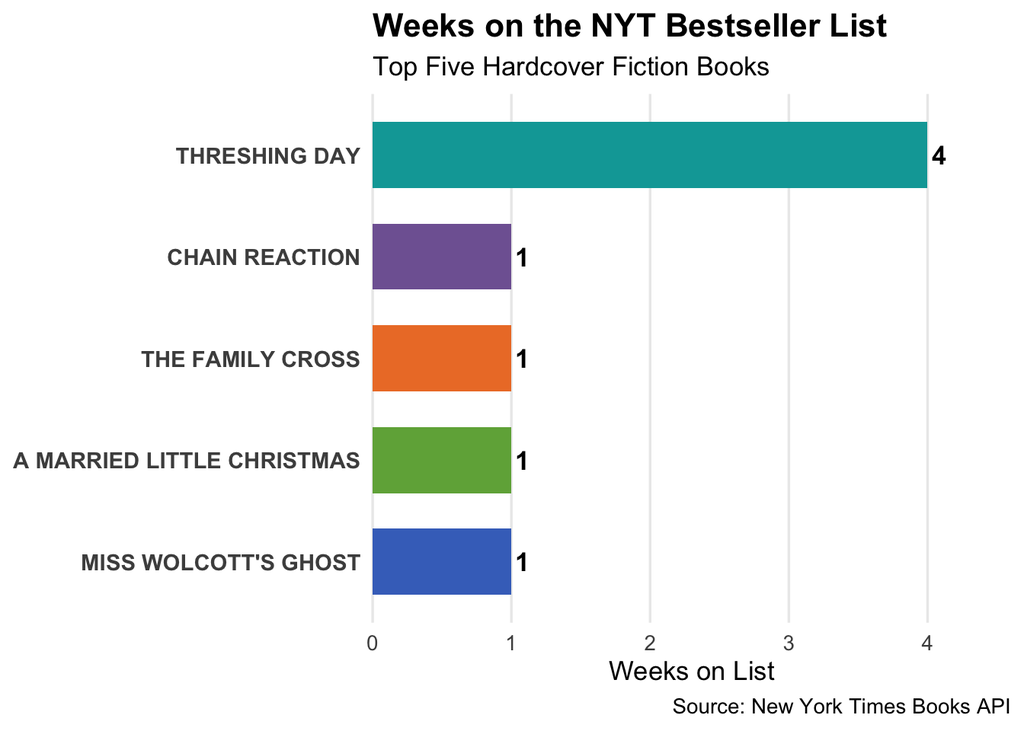

```r
library(ggplot2)
library(dplyr)

# Prepare the data
chart_data <- top_five_analysis %>%
  arrange(weeks_on_list) %>%
  mutate(
    title = factor(title, levels = title)
  )

# Create the chart
ggplot(
  chart_data,
  aes(
    x = title,
    y = weeks_on_list,
    fill = title
  )
) +
  geom_col(
    width = 0.65,
    show.legend = FALSE
  ) +
  geom_text(
    aes(label = weeks_on_list),
    hjust = -0.3,
    size = 4.5,
    fontface = "bold"
  ) +
  scale_fill_manual(
    values = c(
      "#4472C4",
      "#70AD47",
      "#ED7D31",
      "#8064A2",
      "#00A6A6"
    )
  ) +
  coord_flip(clip = "off") +
  scale_y_continuous(
    breaks = seq(
      0,
      max(chart_data$weeks_on_list) + 1,
      1
    ),
    expand = expansion(mult = c(0, 0.15))
  ) +
  labs(
    title = "Weeks on the NYT Bestseller List",
    subtitle = "Top Five Hardcover Fiction Books",
    x = NULL,
    y = "Weeks on List",
    caption = "Source: New York Times Books API"
  ) +
  theme_minimal(base_size = 13) +
  theme(
    plot.title = element_text(
      face = "bold",
      size = 16
    ),
    axis.text.y = element_text(
      size = 11,
      face = "bold"
    ),
    panel.grid.major.y = element_blank(),
    panel.grid.minor = element_blank()
  )
```

### 12.1 Interpretation

“Threshing Day” has been on the bestseller list for four weeks.

The other four books in the top five have been on the list for one week each. This shows that a high ranking does not always mean that a book has remained on the list for a long time.

## 13 Ranking Comparison

In this section, I compare each book’s current ranking with its ranking from the previous week.

A smaller rank number means a higher position on the bestseller list.

```r
ranking_comparison <- books %>%
  mutate(
    rank_change = case_when(
      !is.na(rank_last_week) &
        rank_last_week > 0 ~ rank_last_week - rank,
      TRUE ~ NA_integer_
    ),
    ranking_status = case_when(
      is.na(rank_last_week) |
        rank_last_week == 0 ~ "Not Ranked Last Week",
      rank_change > 0 ~ "Moved Up",
      rank_change < 0 ~ "Moved Down",
      rank_change == 0 ~ "No Change",
      TRUE ~ "Unknown"
    )
  ) %>%
  select(
    rank,
    title,
    rank_last_week,
    rank_change,
    ranking_status
  ) %>%
  arrange(rank)

knitr::kable(
  ranking_comparison,
  col.names = c(
    "Current Rank",
    "Book Title",
    "Previous Rank",
    "Rank Change",
    "Ranking Status"
  ),
  caption = "Current and Previous Bestseller Rankings",
  row.names = FALSE
)
```

Current and Previous Bestseller Rankings

| Current Rank | Book Title | Previous Rank | Rank Change | Ranking Status |
| --- | --- | --- | --- | --- |
| 1 | THRESHING DAY | 1 | 0 | No Change |
| 2 | MISS WOLCOTT’S GHOST | 0 | NA | Not Ranked Last Week |
| 3 | A MARRIED LITTLE CHRISTMAS | 0 | NA | Not Ranked Last Week |
| 4 | THE FAMILY CROSS | 0 | NA | Not Ranked Last Week |
| 5 | CHAIN REACTION | 0 | NA | Not Ranked Last Week |
| 6 | THE FRENCH ILLUSION | 3 | -3 | Moved Down |
| 7 | THE WITCH | 2 | -5 | Moved Down |
| 8 | WITH HEARTS OF FLAME | 0 | NA | Not Ranked Last Week |
| 9 | THE CALAMITY CLUB | 5 | -4 | Moved Down |
| 10 | PARTITA | 6 | -4 | Moved Down |
| 11 | HOLLOW BONES | 8 | -3 | Moved Down |
| 12 | PECK & PECK | 4 | -8 | Moved Down |
| 13 | THE DUNGEON ANARCHIST’S COOKBOOK | 9 | -4 | Moved Down |
| 14 | THE GATE OF THE FERAL GODS | 12 | -2 | Moved Down |
| 15 | MERCY’S CHILD | 0 | NA | Not Ranked Last Week |

### 13.1 Ranking Movement Summary

```r
ranking_summary <- ranking_comparison %>%
  count(ranking_status, name = "number_of_books")

knitr::kable(
  ranking_summary,
  col.names = c(
    "Ranking Status",
    "Number of Books"
  ),
  caption = "Summary of Ranking Changes",
  row.names = FALSE
)
```

Summary of Ranking Changes

| Ranking Status | Number of Books |
| --- | --- |
| Moved Down | 8 |
| No Change | 1 |
| Not Ranked Last Week | 6 |

### 13.2 Interpretation

This comparison shows which books moved up, moved down, or stayed in the same position.

Books with a previous rank of zero or a missing value are classified as “Not Ranked Last Week.” This means they were not ranked on the previous list; it does not necessarily mean they are newly published.

## 14 Results and Discussion

The dataset contains 15 books from the New York Times Hardcover Fiction bestseller list.

I used R to import the JSON data, read the SQLite database, and validate the records.

### 14.1 Research Question 1: Top Five Books

“Threshing Day” by Rebecca Yarros is ranked number one in the saved dataset.

The other books in the top five are “Miss Wolcott’s Ghost,” “A Married Little Christmas,” “The Family Cross,” and “Chain Reaction.”

### 14.2 Research Question 2: Authors

The author analysis shows that Matt Dinniman has two books on the list.

Most other author entries appear once.

### 14.3 Research Question 3: Weeks on the List

“Threshing Day” has been on the bestseller list for four weeks, while the other four top-ranked books have been on the list for one week each.

This shows that a book can have a high ranking even if it has only been on the list for a short time. Rankings and weeks on the list provide different information about each book.

### 14.4 Additional Analysis: Ranking Changes

The ranking comparison shows that 8 books (53.3%) moved down, 1 book (6.7%) stayed in the same position, and 6 books (40.0%) were not ranked on the previous week’s list.

No books moved up in the rankings.

These results show that bestseller rankings can change from one week to another. However, the analysis is limited to one saved bestseller list and its previous-week ranking information.

### 14.5 Data Limitations

This project analyzes one saved bestseller list, not multiple weeks of historical data.

The ranking identifies each book’s position, but the dataset does not include the number of copies sold.

The results describe the saved sample and should not be interpreted as long-term trends.

## 15 Conclusions

In this project, I used the New York Times Books API to collect and analyze bestseller data.

I worked with JSON files, SQLite databases, and R to organize and validate the information.

I identified the top five books, compared authors, examined weeks on the bestseller list, and reviewed changes in rankings.

This project helped me understand how web APIs can provide real-world data for analysis. I also learned the importance of checking data quality and understanding the limitations of the information.

## 16 AI Use

ChatGPT was used to help understand the Week 9 assignment requirements, organize the project approach, and improve the English writing.

It also provided guidance on connecting to the New York Times Books API, reading JSON data in R, creating the SQLite database, and checking the data for missing values and duplicates.

I reviewed the R code, API response, database structure, and preliminary results. The project uses real data from the New York Times Books API.